# 統計勉強会 第11回課題

## 1. ダミー変数の作成

ダミー変数

ダミー変数とは、数字ではないデータを数字に変換する手法。  
具体的には、数字ではないデータを「0」と「1」だけの数列に変換する。

ダミー変数の作成には**caretパッケージ**の**dummyVars関数**が便利らしい。  
（caretパッケージはRで機械学習をするときに使うイメージがある）

### 元データの作成（要caretパッケージ）

```r
df <- data.frame(ID = seq(101, 110, length = 10),
                 性別 = c("男", "女", "男", "男", "女", "男", "男", "女", "男", "女")
                 )
df
```

```
##     ID 性別
## 1  101   男
## 2  102   女
## 3  103   男
## 4  104   男
## 5  105   女
## 6  106   男
## 7  107   男
## 8  108   女
## 9  109   男
## 10 110   女
```

### ダミー変数へ変換

```r
df_dummy <- as.data.frame(predict(dummyVars(~., data = df), df))
df_dummy
```

```
##     ID 性別.女 性別.男
## 1  101       0       1
## 2  102       1       0
## 3  103       0       1
## 4  104       0       1
## 5  105       1       0
## 6  106       0       1
## 7  107       0       1
## 8  108       1       0
## 9  109       0       1
## 10 110       1       0
```

簡単ですね。

## 2. 数量化3類

目的変数のある多変量解析

**数量化1類**：説明変数→カテゴリーデータ 目的変数→数量データ  
（≒ **重回帰分析**：説明変数→数量データ、目的変数→数量データ）

**数量化2類**：説明変数→カテゴリーデータ、目的変数→カテゴリーデータ  
（≒ **判別分析**：説明変数→数量データ、目的変数→カテゴリーデータ）

目的変数のない多変量解析

**数量化3類**：説明変数→カテゴリーデータ、目的変数→なし  
（≒ **主成分分析・因子分析**：説明変数→数量データ、目的変数→なし）

以下において、課題である**数量化3類**と数理的に等価の**コレスポンデンス分析**を行う

### コレスポンデンス分析（要MASSパッケージ）

```r
caith #Rに入ってるデータセット
```

```
##        fair red medium dark black
## blue    326  38    241  110     3
## light   688 116    584  188     4
## medium  343  84    909  412    26
## dark     98  48    403  681    85
```

```r
corresp(caith, nf = 2) #第1主成分と第2主成分の得点
```

```
## First canonical correlation(s): 0.4463684 0.1734554
##
##  Row scores:
##               [,1]       [,2]
## blue   -0.89679252  0.9536227
## light  -0.98731818  0.5100045
## medium  0.07530627 -1.4124778
## dark    1.57434710  0.7720361
##
##  Column scores:
##               [,1]       [,2]
## fair   -1.21871379  1.0022432
## red    -0.52257500  0.2783364
## medium -0.09414671 -1.2009094
## dark    1.31888486  0.5992920
## black   2.45176017  1.6513565
```

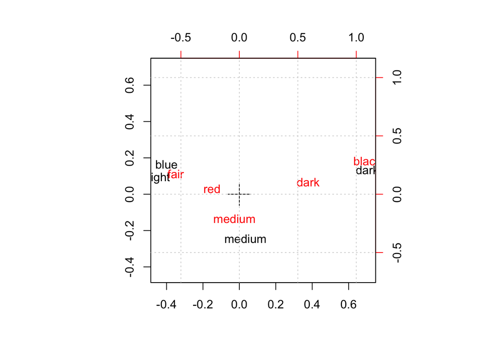

```r
biplot(corresp(caith, nf = 2)) #第1主成分と第2主成分の得点を散布図に
grid()
```

（分析結果）目の色がblue, lightの人はfairが多い、目の色がdarkの人はblackの髪が多い。